# Recognition of Traffic Signs (gTSRb data set)

**Presented by Lucas 519261910010 & Camille 519261910009**

## !!! Due to the maximum size(50MB) for files submission, we just submit the .ipynb and .html files of our project. In order to execute all the codes bellow, you can download the complete dataset and sign names files from our github: [https://github.com/Aph-xin/TrafficSignRec_ml.git]

### The german Traffic Sign Recognition benchmark is a standard labelled dataset of Traffic Signs images cropped from real-world videos recorded on-board of cars. For the mini-project, we resize all images to 32x32 (color) pixels.

More information on the dataset and classification results obtained by various research teams that have participated to the challenges using this benchmark, you can visit the website below:

[http://benchmark.ini.rub.de/?section=gtsrb&subsection=dataset]

```python
import tensorflow.keras
import tensorflow as tf
from keras import regularizers, models, layers, losses
from keras.datasets import mnist # subroutines for fetching the MNIST dataset
from keras.models import Model, Sequential # basic class for specifying and training a neural network
from keras.layers import Input, Conv2D, MaxPooling2D, MaxPool2D, Dense, Dropout, Activation, Flatten
from keras.utils import to_categorical

from sklearn.model_selection import train_test_split
from sklearn.neural_network import MLPClassifier
from sklearn.ensemble import RandomForestClassifier
from sklearn.metrics import classification_report
from sklearn.metrics import confusion_matrix
from sklearn.model_selection import GridSearchCV
#from sklearn.metrics import precision_recall_curve
#from sklearn.metrics import average_precision_score
#from sklearn.metrics import PrecisionRecallDisplay

import pandas as pd
from matplotlib.colors import ListedColormap
#from itertools import cycle
```

```
2022-12-03 16:27:39.696654: I tensorflow/core/platform/cpu_feature_guard.cc:193] This TensorFlow binary is optimized with oneAPI Deep Neural Network Library (oneDNN) to use the following CPU instructions in performance-critical operations:  AVX2 FMA
To enable them in other operations, rebuild TensorFlow with the appropriate compiler flags.
```

## Step 0: Load the images

```python
# FUNCTION FOR LOADING IMAGES
# trainImages, trainLabels = readTrafficSigns('GTSRB/Training')
# print len(trainLabels), len(trainImages)
# plt.imshow(trainImages[42])
# plt.show()
#
# have fun, Christian

import matplotlib.pyplot as plt
import csv

# function for reading the images
# arguments: path to the traffic sign data, for example './GTSRB/Training'
# returns: list of images, list of corresponding labels
def readTrafficSigns(rootpath):
    '''Reads traffic sign data for German Traffic Sign Recognition Benchmark.

    Arguments: path to the traffic sign data, for example './GTSRB/Training'
    Returns:   list of images, list of corresponding labels'''
    images = [] # images
    labels = [] # corresponding labels
    dims = [] # images dims
    rois = [] # strict RoIs of signs
    # loop over all 42 classes
    for c in range(0,43):
        prefix = rootpath + '/' + format(c, '05d') + '/' # subdirectory for class
        gtFile = open(prefix + 'GT-'+ format(c, '05d') + '.csv') # annotations file
        gtReader = csv.reader(gtFile, delimiter=';') # csv parser for annotations file
        next(gtReader) # skip header
        # loop over all images in current annotations file
        for row in gtReader:
            images.append(plt.imread(prefix + row[0])) # the 1th column is the filename
            labels.append(row[7]) # the 8th column is the label
            dims.append( (row[1],row[2]) )
            rois.append( (row[3],row[4],row[5],row[6]) )
        gtFile.close()
    return images, labels, dims, rois
```

### Load training and testing images

```python
# Load training images
img, label, dims, rois = readTrafficSigns('./Training')

# Load testing images
img_tst, label_tst, dims_tst, rois_tst = readTrafficSigns('./Testing')
```

### Resize uniformly training and testing images, shuffle training set, and plot some examples

```
Number of TRAINING examples =  26640
```

```
Number of TESTING examples =  12569
```

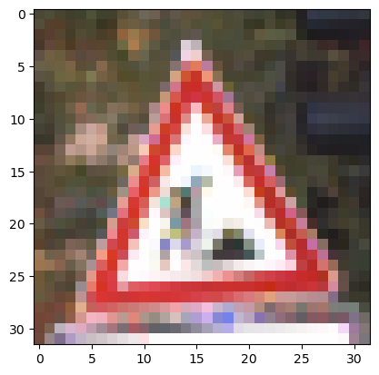

```
25
```

[figure not shown]

```
38
```

[figure not shown]

```
38
```

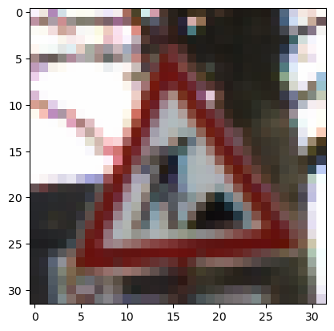

```
25
```

[figure not shown]

```
10
```

```python
import numpy as np
from sklearn.utils import shuffle
import skimage
#from skimage.util import crop
from skimage.transform import resize
from skimage.util import img_as_float32

img_size = 32

# Resize UNIFORMLY all training images
arr_train_img = np.asarray(img)
y_train = np.asarray(label)
X_train_img = arr_train_img
for i in range(0,arr_train_img.size):
  X_train_img[i] = resize(arr_train_img[i], (img_size,img_size) )

# Shuffle the training set (originally ordered by class after loading)
X_train_img, y_train = shuffle(X_train_img, y_train)

# Reformat training set as bi-dimensional array
n_train = X_train_img.shape[0]
input_dim = img_size*img_size*3
X_train = np.zeros( (n_train,input_dim) )
for i in range(0,X_train_img.size):
  X_train[i] = np.ravel( img_as_float32(X_train_img[i], True) )
print("Number of TRAINING examples = ",X_train.shape[0])

# Resize UNIFORMLY all testing images
arr_test_img = np.asarray(img_tst)
y_test = np.asarray(label_tst)
X_test_img = arr_test_img
for i in range(0,arr_test_img.size):
  X_test_img[i] = resize(arr_test_img[i], (img_size,img_size) )

# Reformat testing set as bi-dimensional array
n_test = X_test_img.shape[0]
input_dim = img_size*img_size*3
X_test = np.zeros( (n_test,input_dim) )
for i in range(0,X_test_img.size):
  X_test[i] = np.ravel( img_as_float32(X_test_img[i], True) )
print("Number of TESTING examples = ",X_test.shape[0])

# Visualize some training examples
class_names = label
for i in range(0,5):
  plt.figure()
  plt.imshow(X_train_img[i])
  plt.show()
  print(y_train[i])
```

## Step 1: Dataset Summary

```python
# Data dimensions
print("Number of training examples: ", X_train.shape[0])
print("Number of testing examples: ", X_test.shape[0])
print("Image data shape =", (img_size,img_size,3))
print("Number of classes =", len(set(y_train)))
```

```
Number of training examples:  26640
Number of testing examples:  12569
Image data shape = (32, 32, 3)
Number of classes = 43
```

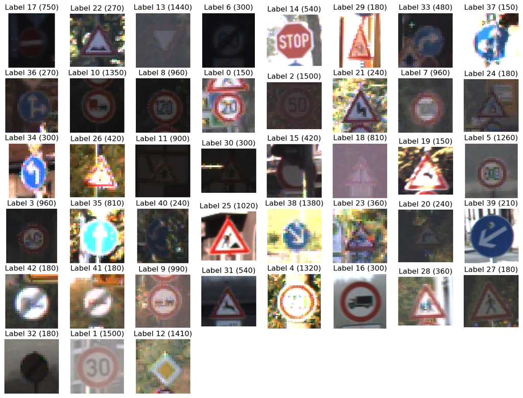

```python
#Python script to display some images
def display_images_and_labels(images, labels):
    """Display the first image of each label."""
    unique_labels = set(labels)
    plt.figure(figsize=(15, 15))
    i = 1
    for label in unique_labels:
        # Pick the first image for each label.
        image = images[labels.index(label)]
        plt.subplot(8, 8, i)  # A grid of 8 rows x 8 columns
        plt.axis('off')
        plt.title("Label {0} ({1})".format(label, labels.count(label)))
        i += 1
        _ = plt.imshow(image)
    plt.show()

display_images_and_labels(img, label)
```

### Data distribution

```python
# Load sign names file
sign_names = pd.read_csv("signnames.csv")
sign_names.set_index("ClassId")

sign_names.head(n=3)
```

|  | ClassId | SignName |
| --- | --- | --- |
| 0 | 0 | Speed limit (20km/h) |
| 1 | 1 | Speed limit (30km/h) |
| 2 | 2 | Speed limit (50km/h) |

```python
# Group images in training set
def group_img_id_to_lbl(lbs_ids, lbs_names):
    """ Utility function to group images by label """
    arr_map = []
    for i in range(0, lbs_ids.shape[0]):
        label_id = lbs_ids[i]
        label_name = lbs_names[lbs_names["ClassId"] == label_id]["SignName"].values[0]
        arr_map.append({"img_id": i, "label_id": label_id, "label_name": label_name})
    return pd.DataFrame(arr_map)

X_train_show = X_train.astype('int64')
X_test_show = X_test.astype('int64')
y_train_show = y_train.astype('int64')
y_test_show = y_test.astype('int64')
X_train_id_to_label = group_img_id_to_lbl(y_train_show, sign_names)

# print those mappings
X_train_id_to_label
```

[output not shown]

26640 rows × 3 columns

| label_id | label_name | img_id |
| --- | --- | --- |
| 0 | Speed limit (20km/h) | 150 |
| 1 | Speed limit (30km/h) | 1500 |
| 2 | Speed limit (50km/h) | 1500 |
| 3 | Speed limit (60km/h) | 960 |
| 4 | Speed limit (70km/h) | 1320 |

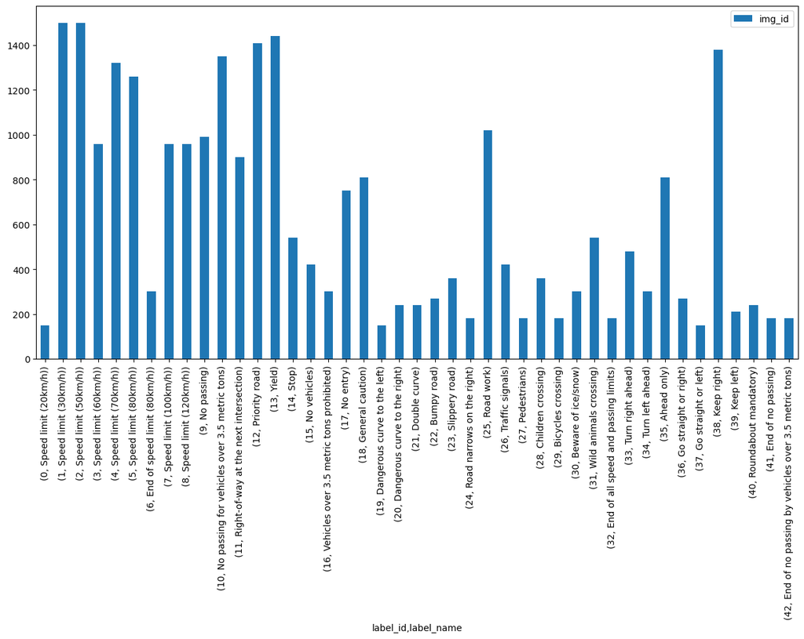

```python
def group_img_id_to_lb_count(img_id_to_lb):
    """ Returns a pivot table table indexed by label id and label name, where the aggregate function is count """
    return pd.pivot_table(img_id_to_lb, index=["label_id", "label_name"], values=["img_id"], aggfunc='count')

# Group by label id to understand the distribution
X_train_group_by_label_count = group_img_id_to_lb_count(X_train_id_to_label)

# Count the number of images for each class and plot the results
X_train_group_by_label_count.plot(kind='bar', figsize=(15, 7))

X_train_group_by_label_count.head(n=5)
```

### Visualization of trainng set image

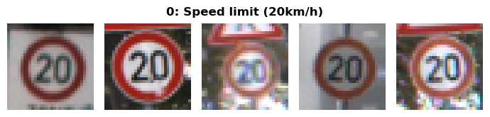

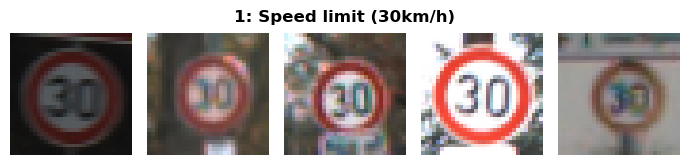

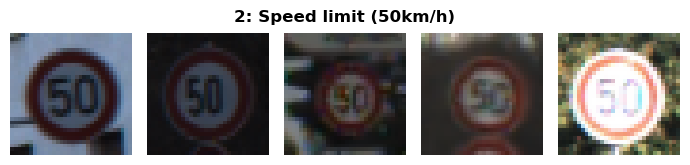

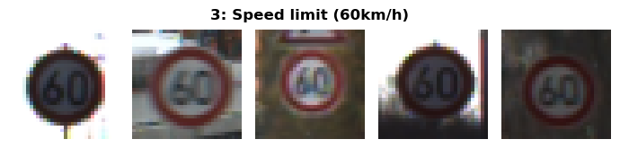

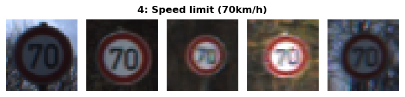

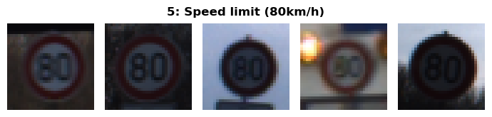

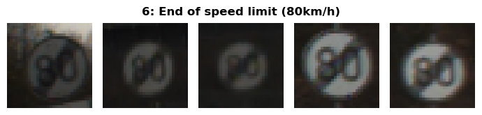

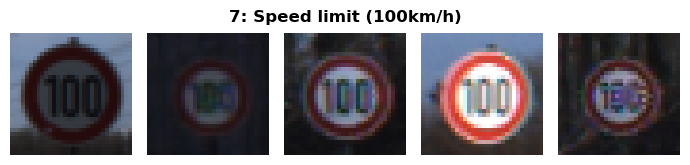

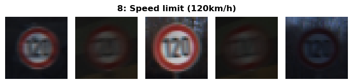

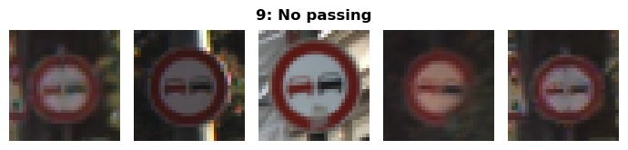

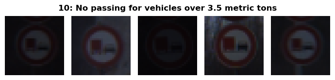

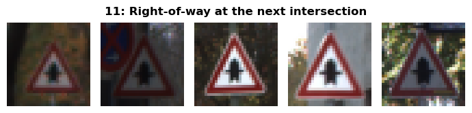

[31 more figures not shown]

```python
# Plot 5 images from each of these classes
def show_image_list(img_list, img_labels, title, cols=2, fig_size=(15, 15), show_ticks=True):
    """ Utility function to show us a list of traffic sign images """
    img_count = len(img_list)
    rows = img_count // cols
    cmap = None
    fig, axes = plt.subplots(rows, cols, figsize=fig_size)
    for i in range(0, img_count):
        img_name = img_labels[i]
        img = img_list[i]
        if len(img.shape) < 3 or img.shape[-1] < 3:
            cmap = "gray"
            img = np.reshape(img, (32, 32, 3))
        if not show_ticks:
            axes[i].axis("off")
        axes[i].imshow(img, cmap=cmap)

    fig.suptitle(title, fontsize=12, fontweight='bold', y = 0.6)
    fig.tight_layout()
    plt.show()
    return

def show_random_dataset_images(group_label, imgs, to_show=5):
    """ This function takes a DataFrame of items group by labels as well as a set of images and randomly selects to_show images to display """
    for (lid, lbl), group in group_label:
        # print("[{0}] : {1}".format(lid, lbl))
        rand_idx = np.random.randint(0, high=group['img_id'].size, size=to_show, dtype='int')
        selected_rows = group.iloc[rand_idx]

        selected_img = list(map(lambda img_id: imgs[img_id], selected_rows['img_id']))
        selected_labels = list(map(lambda label_id: label_id, selected_rows['label_id']))
        show_image_list(selected_img, selected_labels, "{0}: {1}".format(lid, lbl), cols=to_show, fig_size=(7, 7), show_ticks=False)

X_train_group_by_label = X_train_id_to_label.groupby(["label_id", "label_name"])
img_per_class = 5

show_random_dataset_images(X_train_group_by_label, X_train_show)
```

## Step 2: Comparision of algorithms: MLP, Random Forest, ConvNet

In the following part, we will observe the performance of MLP, Random Forest and ConvNet, etc. Since this is a classification problem, the accuracies and confusion-matrices are the main metrics.

### MLP neural-network

Initially, we quick check of MLP scores and loss with the given default settings.

#### 1. The 1st MLP test with default settings

```python
# Data Preparation for MLP
X_train_mlp = X_train.reshape(26640,3072).astype('float32')
X_test_mlp = X_test.reshape(12569,3072).astype('float32')
y_train_mlp = y_train.reshape(26640,).astype('float32')
y_test_mlp = y_test.reshape(12569,).astype('float32')

print("training_shape for MLP: ", X_train_mlp.shape,y_train_mlp.shape)
print("testing_shape for MLP: ", X_test_mlp.shape,y_test_mlp.shape)
```

```
training_shape for MLP:  (26640, 3072) (26640,)
testing_shape for MLP:  (12569, 3072) (12569,)
```

```
Iteration 1, loss = 2.18237237
Iteration 2, loss = 0.96595926
Iteration 3, loss = 0.63137409
Iteration 4, loss = 0.48901257
Iteration 5, loss = 0.39659379
Iteration 6, loss = 0.39831465
Iteration 7, loss = 0.29884389
Iteration 8, loss = 0.27408390
Iteration 9, loss = 0.25166731
Iteration 10, loss = 0.22233852
Iteration 11, loss = 0.20716150
Iteration 12, loss = 0.19532331
Iteration 13, loss = 0.18303115
Iteration 14, loss = 0.22886533
Iteration 15, loss = 0.16198012
Iteration 16, loss = 0.15108058
Iteration 17, loss = 0.14154124
Iteration 18, loss = 0.13970218
Iteration 19, loss = 0.13102150
Iteration 20, loss = 0.12791340
Iteration 21, loss = 0.12364974
Iteration 22, loss = 0.11754017
Iteration 23, loss = 0.12070490
Iteration 24, loss = 0.10237340
Iteration 25, loss = 0.10531033
Iteration 26, loss = 0.10123629
Iteration 27, loss = 0.09094651
Iteration 28, loss = 0.09041318
Iteration 29, loss = 0.08648251
Iteration 30, loss = 0.08060909
```

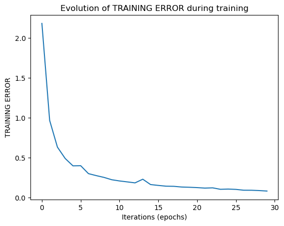

```
Training set score: 0.986674
Test set score: 0.855438
Detailed classification report:
              precision    recall  f1-score   support

         0.0       0.76      0.48      0.59        60
         1.0       0.84      0.89      0.86       720
         2.0       0.89      0.84      0.87       750
         3.0       0.78      0.87      0.83       450
         4.0       0.82      0.82      0.82       660
         5.0       0.65      0.86      0.74       600
         6.0       0.92      0.91      0.91       120
         7.0       0.91      0.83      0.87       480
         8.0       0.90      0.71      0.79       450
         9.0       0.83      0.93      0.88       480
        10.0       0.95      0.96      0.96       660
        11.0       0.89      0.86      0.88       420
        12.0       0.96      0.98      0.97       690
        13.0       0.93      0.93      0.93       720
        14.0       0.98      0.78      0.87       240
        15.0       0.81      0.86      0.83       210
        16.0       1.00      0.53      0.70       120
        17.0       0.88      0.99      0.93       360
        18.0       0.89      0.86      0.88       390
        19.0       0.60      0.88      0.71        60
        20.0       0.57      0.63      0.60       120
        21.0       0.67      0.07      0.12        90
        22.0       0.84      0.94      0.89       120
        23.0       0.70      0.52      0.60       150
        24.0       0.60      0.60      0.60        90
        25.0       0.83      0.94      0.88       480
        26.0       0.77      0.83      0.80       180
        27.0       0.87      0.68      0.77        60
        28.0       0.78      0.84      0.81       180
        29.0       0.51      0.48      0.49        90
        30.0       0.80      0.67      0.73       150
        31.0       0.88      0.74      0.81       240
        32.0       0.72      1.00      0.84        60
        33.0       0.81      0.99      0.89       209
        34.0       0.96      0.99      0.98       120
        35.0       0.99      0.90      0.94       390
        36.0       0.76      0.99      0.86       120
        37.0       0.89      0.95      0.92        60
        38.0       0.96      0.90      0.93       690
        39.0       0.98      0.67      0.79        90
        40.0       0.98      0.68      0.80       120
        41.0       0.71      0.87      0.78        60
        42.0       0.97      0.63      0.77        60

    accuracy                           0.86     12569
   macro avg       0.83      0.80      0.80     12569
weighted avg       0.86      0.86      0.85     12569

CONFUSION MATRIX below
```

```
array([[ 29,  22,   0, ...,   0,   0,   0],
       [  4, 638,  27, ...,   1,   0,   0],
       [  2,  19, 633, ...,   0,   0,   0],
       ...,
       [  0,   8,   1, ...,  81,   3,   0],
       [  0,   0,   0, ...,   0,  52,   0],
       [  0,   0,   0, ...,   0,   9,  38]])
```

```python
mlp = MLPClassifier(hidden_layer_sizes=(100,), max_iter=30, alpha=1e-4,
                    solver='sgd', verbose=10, tol=1e-4, random_state=1,
                    learning_rate_init=0.03)

# Train the MLP classifier on training dataset
mlp.fit(X_train_mlp, y_train_mlp)

# Plot the LEARNING CURVE
plt.title("Evolution of TRAINING ERROR during training")
plt.xlabel("Iterations (epochs)")
plt.ylabel("TRAINING ERROR")
plt.plot(mlp.loss_curve_)
plt.show()

# Evaluate acuracy on test and training data
print("Training set score: %f" % mlp.score(X_train_mlp, y_train_mlp))
print("Test set score: %f" % mlp.score(X_test_mlp, y_test_mlp))
y_pred_mlp = mlp.predict(X_test_mlp)
print("Detailed classification report:")
print(classification_report(y_test_mlp, y_pred_mlp))

# Display CONFUSION MATRIX on TEST set
print("CONFUSION MATRIX below")
confusion_matrix(y_test_mlp, y_pred_mlp)
```

Assume that the first given MLP test does not perform perfectly, we increase the number of iterations with additional early_stopping parameter.

We then use grid-search and cross-validation method to find an optimized combination of learning hyperpaprameters and to avoid the over-fitting. Due to the long training time of the MLP model, we will only show the best set of results here.

```python
%%time
# Define the parameters and values to be tested
param_grid = [
    {'hidden_layer_sizes': [(10,), (50,), (100,)],
    'learning_rate_init':[0.003, 0.03, 0.1],
    'alpha': [0.0001, 0.001]}
    ]

# Cross-validation grid-search (for finding best possible accuracy)
mlp = GridSearchCV( MLPClassifier(max_iter=100,
                    solver='sgd', tol=1e-4, random_state=1,
                    learning_rate_init=0.03, early_stopping=True, validation_fraction=0.4),
                    param_grid, cv=3, scoring='accuracy')

mlp.fit(X_train_mlp, y_train_mlp)
print("Best parameters set found on development set:")
print()
print(mlp.best_params_)
print()
print("Grid scores on development set:")
print()
means = mlp.cv_results_['mean_test_score']
stds = mlp.cv_results_['std_test_score']
for mean, std, params in zip(means, stds, mlp.cv_results_['params']):
    print("%0.3f (+/-%0.03f) for %r"
           % (mean, std * 2, params))
```

[output not shown]

```
Best parameters set found on development set:

{'alpha': 0.001, 'hidden_layer_sizes': (100,), 'learning_rate_init': 0.03}

Grid scores on development set:

0.764 (+/-0.077) for {'alpha': 0.0001, 'hidden_layer_sizes': (10,), 'learning_rate_init': 0.003}
0.564 (+/-0.381) for {'alpha': 0.0001, 'hidden_layer_sizes': (10,), 'learning_rate_init': 0.03}
0.083 (+/-0.077) for {'alpha': 0.0001, 'hidden_layer_sizes': (10,), 'learning_rate_init': 0.1}
0.908 (+/-0.005) for {'alpha': 0.0001, 'hidden_layer_sizes': (50,), 'learning_rate_init': 0.003}
0.934 (+/-0.009) for {'alpha': 0.0001, 'hidden_layer_sizes': (50,), 'learning_rate_init': 0.03}
0.150 (+/-0.014) for {'alpha': 0.0001, 'hidden_layer_sizes': (50,), 'learning_rate_init': 0.1}
0.917 (+/-0.002) for {'alpha': 0.0001, 'hidden_layer_sizes': (100,), 'learning_rate_init': 0.003}
0.944 (+/-0.005) for {'alpha': 0.0001, 'hidden_layer_sizes': (100,), 'learning_rate_init': 0.03}
0.189 (+/-0.082) for {'alpha': 0.0001, 'hidden_layer_sizes': (100,), 'learning_rate_init': 0.1}
0.764 (+/-0.077) for {'alpha': 0.001, 'hidden_layer_sizes': (10,), 'learning_rate_init': 0.003}
0.574 (+/-0.378) for {'alpha': 0.001, 'hidden_layer_sizes': (10,), 'learning_rate_init': 0.03}
0.085 (+/-0.080) for {'alpha': 0.001, 'hidden_layer_sizes': (10,), 'learning_rate_init': 0.1}
0.908 (+/-0.005) for {'alpha': 0.001, 'hidden_layer_sizes': (50,), 'learning_rate_init': 0.003}
0.937 (+/-0.006) for {'alpha': 0.001, 'hidden_layer_sizes': (50,), 'learning_rate_init': 0.03}
0.176 (+/-0.084) for {'alpha': 0.001, 'hidden_layer_sizes': (50,), 'learning_rate_init': 0.1}
0.917 (+/-0.002) for {'alpha': 0.001, 'hidden_layer_sizes': (100,), 'learning_rate_init': 0.003}
0.946 (+/-0.005) for {'alpha': 0.001, 'hidden_layer_sizes': (100,), 'learning_rate_init': 0.03}
0.206 (+/-0.034) for {'alpha': 0.001, 'hidden_layer_sizes': (100,), 'learning_rate_init': 0.1}
CPU times: user 1h 43min 11s, sys: 6min 21s, total: 1h 49min 32s
Wall time: 29min 6s
```

### 2. The 2nd MLP test with best_param

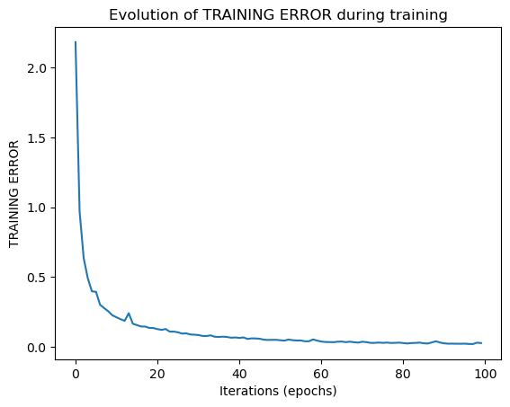

```
Training set score: 0.994219
Test set score: 0.860769
Detailed classification report:
              precision    recall  f1-score   support

         0.0       0.59      0.63      0.61        60
         1.0       0.73      0.93      0.82       720
         2.0       0.86      0.83      0.84       750
         3.0       0.90      0.75      0.81       450
         4.0       0.77      0.87      0.82       660
         5.0       0.82      0.80      0.81       600
         6.0       0.92      0.91      0.92       120
         7.0       0.86      0.88      0.87       480
         8.0       0.82      0.89      0.85       450
         9.0       0.90      0.94      0.92       480
        10.0       0.95      0.97      0.96       660
        11.0       0.89      0.84      0.86       420
        12.0       1.00      0.97      0.98       690
        13.0       0.96      0.92      0.94       720
        14.0       0.99      0.81      0.89       240
        15.0       0.90      0.81      0.85       210
        16.0       0.98      0.71      0.82       120
        17.0       0.90      0.97      0.93       360
        18.0       0.93      0.80      0.86       390
        19.0       0.85      0.88      0.87        60
        20.0       0.66      0.62      0.64       120
        21.0       0.19      0.03      0.06        90
        22.0       0.91      0.93      0.92       120
        23.0       0.66      0.61      0.63       150
        24.0       0.55      0.66      0.60        90
        25.0       0.91      0.91      0.91       480
        26.0       0.61      0.91      0.73       180
        27.0       0.80      0.72      0.75        60
        28.0       0.86      0.82      0.84       180
        29.0       0.64      0.41      0.50        90
        30.0       0.62      0.79      0.69       150
        31.0       0.80      0.73      0.76       240
        32.0       0.71      1.00      0.83        60
        33.0       0.87      0.99      0.92       209
        34.0       0.96      0.98      0.97       120
        35.0       0.98      0.91      0.95       390
        36.0       0.81      1.00      0.89       120
        37.0       0.62      0.98      0.76        60
        38.0       0.99      0.86      0.92       690
        39.0       0.97      0.86      0.91        90
        40.0       0.83      0.75      0.79       120
        41.0       0.69      0.87      0.77        60
        42.0       0.97      0.65      0.78        60

    accuracy                           0.86     12569
   macro avg       0.82      0.82      0.81     12569
weighted avg       0.87      0.86      0.86     12569

CONFUSION MATRIX below
```

```
array([[ 38,  14,   0, ...,   0,   0,   0],
       [  7, 667,  15, ...,   0,   0,   0],
       [  2,  41, 621, ...,   0,   0,   0],
       ...,
       [  0,  20,   0, ...,  90,   0,   0],
       [  0,   0,   0, ...,   0,  52,   0],
       [  0,   0,   0, ...,   0,  11,  39]])
```

```python
mlp = MLPClassifier(hidden_layer_sizes=(100,), max_iter=100, alpha=1e-3,
                    solver='sgd', tol=1e-4, random_state=1,
                    learning_rate_init=0.03)

# Train the MLP classifier on training dataset
mlp.fit(X_train_mlp, y_train_mlp)

# Plot the LEARNING CURVE
plt.title("Evolution of TRAINING ERROR during training")
plt.xlabel("Iterations (epochs)")
plt.ylabel("TRAINING ERROR")
plt.plot(mlp.loss_curve_)
plt.show()

# Evaluate acuracy on test and training data
print("Training set score: %f" % mlp.score(X_train_mlp, y_train_mlp))
print("Test set score: %f" % mlp.score(X_test_mlp, y_test_mlp))
y_pred_mlp = mlp.predict(X_test_mlp)
print("Detailed classification report:")
print(classification_report(y_test_mlp, y_pred_mlp))

# Display CONFUSION MATRIX on TEST set
print("CONFUSION MATRIX below")
confusion_matrix(y_test_mlp, y_pred_mlp)
```

With one huge hidden layer, MLP can be applied in various situations. From the scores and the figures above that, MLP model does converge with 99% training accuracy and 86% test accuracy. Furthermore, from the learning curve of the 100 samples, the model tends to converge more smoothly than our first test. This is why we can choose MLP as our baseline.

### Random Forest Classifier

As one of the ensemble method, we assume the RF should have a better result than the baseline model. In order to test the RF model, we applied GridSearchCV in order to find the best combination of hyperparameters. Due to the long training time of the RFC model, we will only show the best set of results here.

```python
# Data Preparation for Random forest classifier
X_train_rfc = X_train.reshape(26640,3072).astype('float32')
X_test_rfc = X_test.reshape(12569,3072).astype('float32')
y_train_rfc = y_train.reshape(26640,).astype('float32')
y_test_rfc = y_test.reshape(12569,).astype('float32')

print("training_shape for RFC: ", X_train_rfc.shape,y_train_rfc.shape)
print("testing_shape for RFC: ", X_test_rfc.shape,y_test_rfc.shape)
```

```
training_shape for RFC:  (26640, 3072) (26640,)
testing_shape for RFC:  (12569, 3072) (12569,)
```

```python
%%time
# Define the parameters and values to be tested
parameters = {
            'max_depth':[90,100,110],
            'min_samples_split':[4,8,10],
            'n_estimators':[100,150,200]}

# Initialize a Random Forest Classifier
dtc=RandomForestClassifier()

# Initialize the cross-validation by GridSearchCV
rfc = GridSearchCV(dtc, parameters)

# Now, run cross-validation on the TRAINING set
rfc.fit(X_train_rfc, y_train_rfc)
print(rfc.score(X_test_rfc, y_test_rfc))
print(rfc.best_params_) # Best possible
```

It took too long to execute the code above, so by manually adjusting the hyperparameters, we compare the performances and selected the best possible set.

#### 1. RFC test with best_param

```python
# Create and train a Random Forest classifier
rfc = RandomForestClassifier(n_estimators=200, max_depth=110,
                            min_samples_split=10, max_features='sqrt',
                            class_weight='balanced', n_jobs=3)
# Train the RFC on training dataset
rfc.fit(X_train_rfc, y_train_rfc)

# Evaluate accuracy on test and training data
print("Training set score: %f" % rfc.score(X_train_rfc, y_train_rfc))
print("Test set score: %f" % rfc.score(X_test_rfc, y_test_rfc))
y_pred_rfc = rfc.predict(X_test_rfc)
print("Detailed classification report:")
print(classification_report(y_test_rfc, y_pred_rfc))

# Display CONFUSION MATRIX on TEST set
print("CONFUSION MATRIX below")
confusion_matrix(y_test_rfc, y_pred_rfc)
```

```
Training set score: 1.000000
Test set score: 0.749463
Detailed classification report:
              precision    recall  f1-score   support

         0.0       1.00      0.10      0.18        60
         1.0       0.65      0.90      0.75       720
         2.0       0.56      0.68      0.61       750
         3.0       0.68      0.62      0.65       450
         4.0       0.79      0.75      0.77       660
         5.0       0.51      0.61      0.56       600
         6.0       0.80      0.87      0.83       120
         7.0       0.58      0.66      0.61       480
         8.0       0.47      0.42      0.44       450
         9.0       0.91      0.88      0.90       480
        10.0       0.96      0.83      0.89       660
        11.0       0.91      0.85      0.88       420
        12.0       0.98      0.97      0.97       690
        13.0       0.89      0.95      0.92       720
        14.0       0.92      0.77      0.84       240
        15.0       0.95      0.55      0.69       210
        16.0       0.98      0.74      0.84       120
        17.0       0.85      0.96      0.90       360
        18.0       0.64      0.66      0.65       390
        19.0       0.22      0.25      0.24        60
        20.0       0.81      0.62      0.70       120
        21.0       0.67      0.34      0.46        90
        22.0       0.94      0.88      0.91       120
        23.0       0.43      0.29      0.35       150
        24.0       0.86      0.61      0.71        90
        25.0       0.72      0.91      0.81       480
        26.0       0.67      0.61      0.64       180
        27.0       0.41      0.52      0.46        60
        28.0       0.77      0.56      0.65       180
        29.0       0.87      0.52      0.65        90
        30.0       0.49      0.56      0.53       150
        31.0       0.51      0.45      0.48       240
        32.0       0.17      0.08      0.11        60
        33.0       0.79      1.00      0.88       209
        34.0       0.98      0.74      0.84       120
        35.0       0.89      0.92      0.90       390
        36.0       1.00      0.98      0.99       120
        37.0       0.98      1.00      0.99        60
        38.0       0.91      0.90      0.90       690
        39.0       1.00      0.28      0.43        90
        40.0       0.97      0.50      0.66       120
        41.0       0.57      0.57      0.57        60
        42.0       0.57      0.35      0.43        60

    accuracy                           0.75     12569
   macro avg       0.75      0.66      0.68     12569
weighted avg       0.76      0.75      0.75     12569

CONFUSION MATRIX below
```

```
array([[  6,  44,   0, ...,   0,   0,   0],
       [  0, 649,  36, ...,   0,   0,   0],
       [  0,  47, 507, ...,   0,   0,   0],
       ...,
       [  0,   5,  28, ...,  60,   0,   0],
       [  0,   6,   1, ...,   0,  34,   0],
       [  0,   0,   0, ...,   0,   0,  21]])
```

### CNN

CNN as an efficient way for image classification will be applied here.

```python
# Data Preparation for ConvNet
X_train_cnn = X_train.reshape(26640,32,32,3).astype('float32')
X_test_cnn = X_test.reshape(12569,32,32,3).astype('float32')
y_train_cnn = y_train.reshape(26640,1).astype('float32')
y_test_cnn = y_test.reshape(12569,1).astype('float32')

print("training_shape for ConvNet: ", X_train_cnn.shape,y_train_cnn.shape)
print("testing_shape for ConvNet: ", X_test_cnn.shape,y_test_cnn.shape)
```

```
training_shape for ConvNet:  (26640, 32, 32, 3) (26640, 1)
testing_shape for ConvNet:  (12569, 32, 32, 3) (12569, 1)
```

#### 1. The 1st CNN test with default settings

Firstly, without overfitting prevention methods like dropout and regularization, the performance of ConvNet model is tested by the accuracies and losses curves.

```python
# Network params
batch_size = 32    # in each iteration, we consider 32 training examples at once
num_epochs = 20    # we iterate 20 times over the entire training set
kernel_size = 5    # we will use 5x5 kernels throughout
pool_size = 2      # we will use 2x2 pooling throughout
conv_depth_1 = 6   # we will initially have 6 kernels in first conv. layer...
conv_depth_2 = 16  # ...switching to 16 after the first pooling layer
drop_prob_1 = 0.   # dropout after pooling with probability 0.
drop_prob_2 = 0.   # dropout in the FC layer with probability 0.
hidden_size = 128  # the FC layer will have 128neurons
weight_penalty = 0. # Factor for weights penalty
num_classes = 43    # Number of classes

model = Sequential()
# Conv [8] -> Pool (without dropout on the pooling layer)
model.add( Conv2D(conv_depth_1, (kernel_size,kernel_size), padding='same', activation='relu', data_format="channels_last", input_shape=( 32, 32, 3)) )
model.add( MaxPooling2D(pool_size=(pool_size, pool_size)) )
model.add( Dropout(drop_prob_1) )

# Conv [16] -> Pool (without dropout on the pooling layer)
model.add( Conv2D(conv_depth_2, (kernel_size,kernel_size), padding='same', activation='relu') )
model.add( MaxPooling2D(pool_size=(pool_size, pool_size)) )
model.add( Dropout(drop_prob_1) )

# Now flatten to 1D, apply FC -> ReLU (without dropout) -> softmax
model.add( Flatten() )
model.add( Dense(hidden_size, activation='relu', kernel_regularizer=regularizers.l2(weight_penalty)) )
model.add( Dropout(drop_prob_2) )
model.add( Dense(num_classes, activation='softmax') )

print(model.summary())

# Compile Model
model.compile(loss='sparse_categorical_crossentropy',
            optimizer='adam',
            metrics=['accuracy'])

# Train Model
epochs = 8
history = model.fit(X_train_cnn, y_train_cnn,
                    epochs=epochs, batch_size=64,
                    verbose=1, validation_split=0.4)

# Evaluate Model
for loss_name, loss_value in list(zip(model.metrics_names, model.evaluate(X_train_cnn, y_train_cnn, verbose=1))):
    print('The final {} on the TRAINING set is: {:.2f}.'.format(loss_name, loss_value))
for loss_name, loss_value in list(zip(model.metrics_names, model.evaluate(X_test_cnn, y_test_cnn, verbose=1))):
    print('The final {} on the TEST set is: {:.2f}.'.format(loss_name, loss_value)) # Evaluate the trained model on the test set!
```

```
Model: "sequential_3"
_________________________________________________________________
 Layer (type)                Output Shape              Param #
=================================================================
 conv2d_10 (Conv2D)          (None, 32, 32, 6)         456

 max_pooling2d_6 (MaxPooling  (None, 16, 16, 6)        0
 2D)

 dropout_9 (Dropout)         (None, 16, 16, 6)         0

 conv2d_11 (Conv2D)          (None, 16, 16, 16)        2416

 max_pooling2d_7 (MaxPooling  (None, 8, 8, 16)         0
 2D)

 dropout_10 (Dropout)        (None, 8, 8, 16)          0

 flatten_3 (Flatten)         (None, 1024)              0

 dense_6 (Dense)             (None, 128)               131200

 dropout_11 (Dropout)        (None, 128)               0

 dense_7 (Dense)             (None, 43)                5547

=================================================================
Total params: 139,619
Trainable params: 139,619
Non-trainable params: 0
_________________________________________________________________
None
The final loss on the TRAINING set is: 0.10.
The final accuracy on the TRAINING set is: 0.97.
The final loss on the TEST set is: 0.63.
The final accuracy on the TEST set is: 0.85.
```

[figure not shown]

[figure not shown]

```python
# Accuracy & Loss functions evolution
plt.figure(0)
plt.plot(history.history['accuracy'], label="Training accuracy")
plt.plot(history.history['val_accuracy'], label="Val accuracy")
plt.title("Accuracy Graph")
plt.xlabel("epochs")
plt.ylabel("accuracy (0,1)")
plt.legend()

plt.figure(1)
plt.plot(history.history['loss'], label="Training loss")
plt.plot(history.history['val_loss'], label="Val loss")
plt.title("Loss Graph")
plt.xlabel("epochs")
plt.ylabel("Loss")
plt.legend()
plt.show()
```

In the initial test of CNN, the accuracy of test set is much lower and the over-fitting may begin to occur at the 3rd epoch. In order to mitigate over-fitting, the dropout and regularization should be performed. After several trials of CNN architectures, the optimal CNN design with the greatest accuracy is shown as follows.

#### 2. The 2nd CNN test with optimal settings

```python
# The optimal CNN architecture
model = tf.keras.Sequential()
# Conv -> Pool (with dropout on the pooling layer)
model.add(Conv2D(filters=32, kernel_size=(5,5), activation='relu', input_shape=X_train_cnn.shape[1:]))
model.add(Conv2D(filters=32, kernel_size=(5,5), activation='relu'))
model.add(MaxPool2D(pool_size=(2, 2)))
model.add(Dropout(rate=0.25))

# Conv -> Pool (with dropout on the pooling layer)
model.add(Conv2D(filters=64, kernel_size=(3,3), activation='relu'))
model.add(Conv2D(filters=64, kernel_size=(3,3), activation='relu'))
model.add(MaxPool2D(pool_size=(2, 2)))
model.add(Dropout(rate=0.25))

# Now flatten to 1D, apply FC -> ReLU (with dropout) -> softmax
model.add(Flatten())
model.add(Dense(256, activation='relu'))
model.add(Dropout(rate=0.5))
model.add(Dense(43, activation='softmax'))

# Model display
model.summary()

# Compile Model
model.compile(loss='sparse_categorical_crossentropy',
            optimizer='adam',
            metrics=['accuracy'])

# Train Model
epochs = 8
history = model.fit(X_train_cnn, y_train_cnn,
                    epochs=epochs, batch_size=64,
                    verbose=1, validation_split=0.4)

# Evaluate Model
for loss_name, loss_value in list(zip(model.metrics_names, model.evaluate(X_train_cnn, y_train_cnn, verbose=1))):
    print('The final {} on the TRAINING set is: {:.2f}.'.format(loss_name, loss_value))
for loss_name, loss_value in list(zip(model.metrics_names, model.evaluate(X_test_cnn, y_test_cnn, verbose=1))):
    print('The final {} on the TEST set is: {:.2f}.'.format(loss_name, loss_value)) # Evaluate the trained model on the test set!
```

```
Model: "sequential_4"
_________________________________________________________________
 Layer (type)                Output Shape              Param #
=================================================================
 conv2d_12 (Conv2D)          (None, 28, 28, 32)        2432

 conv2d_13 (Conv2D)          (None, 24, 24, 32)        25632

 max_pooling2d_8 (MaxPooling  (None, 12, 12, 32)       0
 2D)

 dropout_12 (Dropout)        (None, 12, 12, 32)        0

 conv2d_14 (Conv2D)          (None, 10, 10, 64)        18496

 conv2d_15 (Conv2D)          (None, 8, 8, 64)          36928

 max_pooling2d_9 (MaxPooling  (None, 4, 4, 64)         0
 2D)

 dropout_13 (Dropout)        (None, 4, 4, 64)          0

 flatten_4 (Flatten)         (None, 1024)              0

 dense_8 (Dense)             (None, 256)               262400

 dropout_14 (Dropout)        (None, 256)               0

 dense_9 (Dense)             (None, 43)                11051

=================================================================
Total params: 356,939
Trainable params: 356,939
Non-trainable params: 0
_________________________________________________________________
The final loss on the TRAINING set is: 0.02.
The final accuracy on the TRAINING set is: 1.00.
The final loss on the TEST set is: 0.11.
The final accuracy on the TEST set is: 0.98.
```

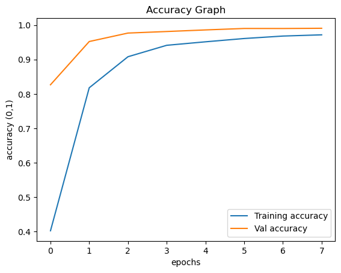

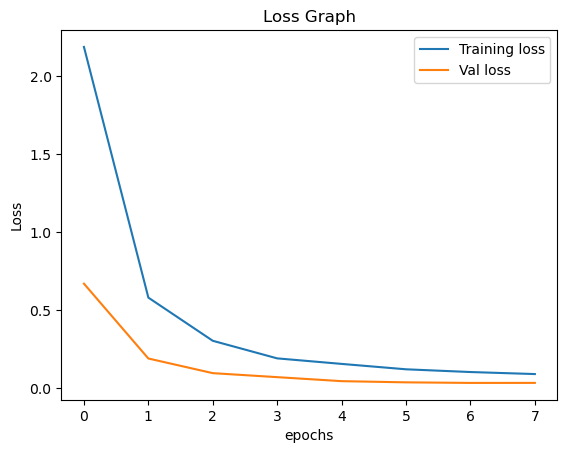

```python
# Accuracy & Loss functions evolution
plt.figure(0)
plt.plot(history.history['accuracy'], label="Training accuracy")
plt.plot(history.history['val_accuracy'], label="Val accuracy")
plt.title("Accuracy Graph")
plt.xlabel("epochs")
plt.ylabel("accuracy (0,1)")
plt.legend()

plt.figure(1)
plt.plot(history.history['loss'], label="Training loss")
plt.plot(history.history['val_loss'], label="Val loss")
plt.title("Loss Graph")
plt.xlabel("epochs")
plt.ylabel("Loss")
plt.legend()
plt.show()
```

From the training results, we witness that ConvNet model can achieve the best performance topping the 98% test accuracy. Besides, we can see on the graph of Loss vs Epochs that the losses of training and validation set get closer as the epochs go by, which would indicate that overfitting is mitigated by dropout method and ConvNet model generalises well to extract features.

## STEP 3: Conclusion

In this project, given the characterics of the traffic signs dataset and the additional sign name .csv file, the data distribution of training set images grouped by classes is demonstrated intuitively by the visualization. Furthermore, in order to analyze which algorithms should be more appropriate, we applied one basic classifiers which are ConvNet classifier, and tested one boosting models which are Random Forest. One neural-liked model MLP was also performed. Throughout the process, we not only pay attention to the exploration by cross-validation, separate validation subset of the possible values for the main hyper-parameters of each algorithm, but also try our best to avoid over-fitting by taking appropriate action such as regularization penalty, dropout, etc. Besides, we take the standard detailed metrics into consideration for comparison between results (not only accuracies, but also precisions, recalls, confusion-matrices, etc.)

ConvNet model owns the best performance in comparison with the other two baselines, MLP and Randwom forest. The overall results (accuracies) are shown below:

```python
print("MLP neural netwrok:")
print("Training accuracy:" + str(0.99))
print("Test accuracy:" + str(0.86))
print("==============================")

print("Random forest classifier:")
print("Training accuracy:" + str(1.00))
print("Test accuracy:" + str(0.75))
print("==============================")

print("ConvNet:")
print("Training accuracy:" + str(1.00))
print("Test accuracy:" + str(0.98))
```

```
MLP neural netwrok:
Training accuracy:0.99
Test accuracy:0.86
==============================
Random forest classifier:
Training accuracy:1.0
Test accuracy:0.75
==============================
ConvNet:
Training accuracy:1.0
Test accuracy:0.98
```